# POLI 572B

Michael Weaver

January 19, 2024

# Potential Outcomes Model and Sampling Variability

## Plan for Today

# Review

## Key ideas from last week

- Potential Outcomes Model (and Neyman Causal Model)
- Partial and Point Identification
- Reviewed **random variables** and their expectations

## Potential Outcomes and Causal effects

We never observe unit causal effects, but can estimate average causal effect, by filling in missing ($\color{red}{\text{counterfactual}}$) potential outcomes.

$$\begin{equation}\begin{split}ACE &=
\{E[Y_i(1)|Z_i = 1]\pi_1 + \overbrace{\color{red}{E[Y_i(1)|Z_i =
0]}}^{\text{Mean Y(1) for untreated}}\pi_0\} \\ & \phantom{=}\ -
\{\underbrace{\color{red}{E[Y_i(0)|Z_i = 1]}}_{\text{Mean Y(0) for
treated}}\pi_1 + E[Y_i(0)|Z_i = 0]\pi_0\} \end{split}
\end{equation}$$

## Partial Identification

Given assumptions, we fill in the maximum/minimum logically possible values for missing potential outcomes to get **bounds**. Bounds must contain the true causal effect if the assumptions are true.

## Random Variables

**random variable**: a *chance* procedure for generating a number

**observed value** (**realization**): value of a particular draw of a random variable.

## Random Variables

1. Arithmetic operations on random variables are new random variables (e.g., sum and mean)
2. **Expected value** of a random variable $X$ is the mean of all possible realizations of $X$
3. Independence and Dependence: random variables $X,Y$ are independent if knowing value of $X$ does not yield information about value of $Y$.
4. Mean of $n$ realizations (sample) from random variable $X$ is also a random variable, with mean same as $E[X]$. (*intuition for proof*?)

## Point Identification

- Random assignment of $Z$ lets us plug in sample means for unobserved potential outcomes: Why?

$$\begin{equation}\begin{split}ACE &=
\{E[Y_i(1)|Z_i = 1]\pi_1 + \overbrace{\color{red}{E[Y_i(1)|Z_i =
0]}}^{\text{plug in Y(1) for treated}}\pi_0\} \\ & \phantom{=}\ -
\{\underbrace{\color{red}{E[Y_i(0)|Z_i = 1]}}_{\text{plug in Y(0) for
untreated}}\pi_1 + E[Y_i(0)|Z_i = 0]\pi_0\} \end{split}
\end{equation}$$

## BUT…

- … random assignment **does not guarantee** that any **particular** randomization gives us exact estimate of unobserved potential outcomes
- different realizations of random process $\to$ **sampling variability**

The extent of sampling variability depends on the nature of the **random process** that generates observations.

## Sampling variability

In any given randomization, **treatment mean** and **control mean** are likely $\neq$ the true means of $Y(1)$ and $Y(0)$…

We want to know:

1. By how much are the sample means likely to deviate from true average causal effect?
2. Given $\widehat{ACE}$, how confident can we be that $ACE \neq 0$

## Key idea

### Sampling Distribution of the Mean

- What is it?
- We’ll do an example

## Bonus idea

### Unbiasedness of $\widehat{ACE}$

**parameter**/**estimand**: unknown attribute of random variable (e.g., the mean) that we want to know

**estimator**: rule/procedure for **estimating** the parameter/estimand given observed data

**bias**: estimator is **biased** if, on average, the estimator yields a value different from the parameter

So $\widehat{ACE}$ is unbiased if:

$$E(\widehat{ACE}) - ACE = 0$$

# Example

## Paluck (2010)

Following evidence of effects of soap opera in Rwanda (2009):

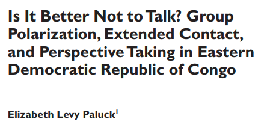

## Paluck (2010)

Variation on Rwandan study, in Eastern DRC.

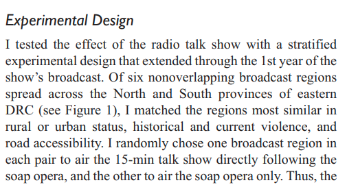

## Paluck (2010)

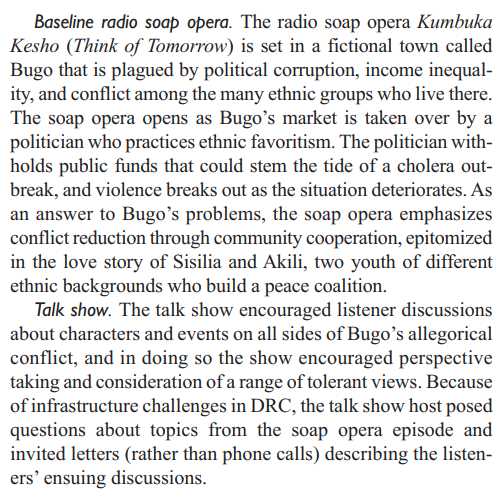

## Paluck (2010)

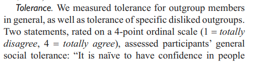

## Paluck (2010)

> Intolerance: “I would not like that group to belong to my community association”; (1 = totally disagree; 4 = totally agree)

| $Region_i$ | $Y_i(1)$ | $Y_i(0)$ |
| --- | --- | --- |
| 1 | 3 | 2 |
| 2 | 4 | 4 |
| 3 | 4 | 2 |
| 4 | 2 | 3 |
| 5 | 2 | 4 |
| 6 | 4 | 1 |

## What are the unit treatment effects? ($\tau_i$)

| $Region_i$ | $Y_i(1)$ | $Y_i(0)$ |
| --- | --- | --- |
| 1 | 3 | 2 |
| 2 | 4 | 4 |
| 3 | 4 | 2 |
| 4 | 2 | 3 |
| 5 | 2 | 4 |
| 6 | 4 | 1 |

## What is the Average Causal Effect ($ACE$)?

| $Region_i$ | $Y_i(1)$ | $Y_i(0)$ |
| --- | --- | --- |
| 1 | 3 | 2 |
| 2 | 4 | 4 |
| 3 | 4 | 2 |
| 4 | 2 | 3 |
| 5 | 2 | 4 |
| 6 | 4 | 1 |

## Imagine we run this experiment

- We set 3 regions in treatment (soap opera + talk show)
- We set 3 regions in control (soap opera only)
- How many possible random assignments are there?
- What are all possible random assignments (to treatment and control)?
  - on paper/in `R`

## All possible treatment groups

### All possible treatment groups

| 1 | 2 | 3 |
| --- | --- | --- |
| 1 | 2 | 4 |
| 1 | 2 | 5 |
| 1 | 2 | 6 |
| 1 | 3 | 4 |
| 1 | 3 | 5 |
| 1 | 3 | 6 |
| 1 | 4 | 5 |
| 1 | 4 | 6 |
| 1 | 5 | 6 |
| 2 | 3 | 4 |
| 2 | 3 | 5 |
| 2 | 3 | 6 |
| 2 | 4 | 5 |
| 2 | 4 | 6 |
| 2 | 5 | 6 |
| 3 | 4 | 5 |
| 3 | 4 | 6 |
| 3 | 5 | 6 |
| 4 | 5 | 6 |

For each randomization, calculate the $\widehat{ACE}$ (hint, express this in fractions $\frac{x}{3}$)

| $Region_i$ | $Y_i(1)$ | $Y_i(0)$ |
| --- | --- | --- |
| 1 | 3 | 2 |
| 2 | 4 | 4 |
| 3 | 4 | 2 |
| 4 | 2 | 3 |
| 5 | 2 | 4 |
| 6 | 4 | 1 |

### Across all randomizations…

- What is the mean $\widehat{ACE}$?
- How does it compare to the $ACE$?
- Are there any $\widehat{ACE} = ACE$

Let’s check our work:

```r
require(data.table) #data.table function

p_o_table = data.table(region_i = 1:6,
                       y_i_1 = c(3,4,4,2,2,4),
                       y_i_0 = c(2,4,2,3,4,1)
                      )
p_o_table$tau_i = p_o_table$y_i_1 - p_o_table$y_i_0
p_o_table[, tau_i := y_i_1 - y_i_0]

#ACE
ace = mean(p_o_table$tau_i)
ace
```

```
## [1] 0.5
```

Let’s check our work:

```r
require(ri) #combn is a function in this package
require(magrittr) # %>% is from this package

randomizations = combn(6,3,simplify = T) %>% t

t_means = apply(randomizations, 1,
                function(x)
                  mean(p_o_table[region_i %in% x, y_i_1])
                )

c_means = apply(randomizations, 1,
                function(x)
                  mean(p_o_table[!(region_i %in% x), y_i_0])
                )
```

Let’s check our work:

```r
t_means
```

```
##  [1] 3.666667 3.000000 3.000000 3.666667 3.000000 3.000000 3.666667 2.333333
##  [9] 3.000000 3.000000 3.333333 3.333333 4.000000 2.666667 3.333333 3.333333
## [17] 2.666667 3.333333 3.333333 2.666667
```

```r
c_means
```

```
##  [1] 2.666667 2.333333 2.000000 3.000000 3.000000 2.666667 3.666667 2.333333
##  [9] 3.333333 3.000000 2.333333 2.000000 3.000000 1.666667 2.666667 2.333333
## [17] 2.333333 3.333333 3.000000 2.666667
```

Let’s check our work:

```r
#Average Causal Effects (hat)
ace_hats = t_means - c_means

#Expected value of the ACE (hat)
e_ace_hat = mean(ace_hats)
e_ace_hat
```

```
## [1] 0.5
```

```r
#ACE
ace
```

```
## [1] 0.5
```

Let’s check our work:

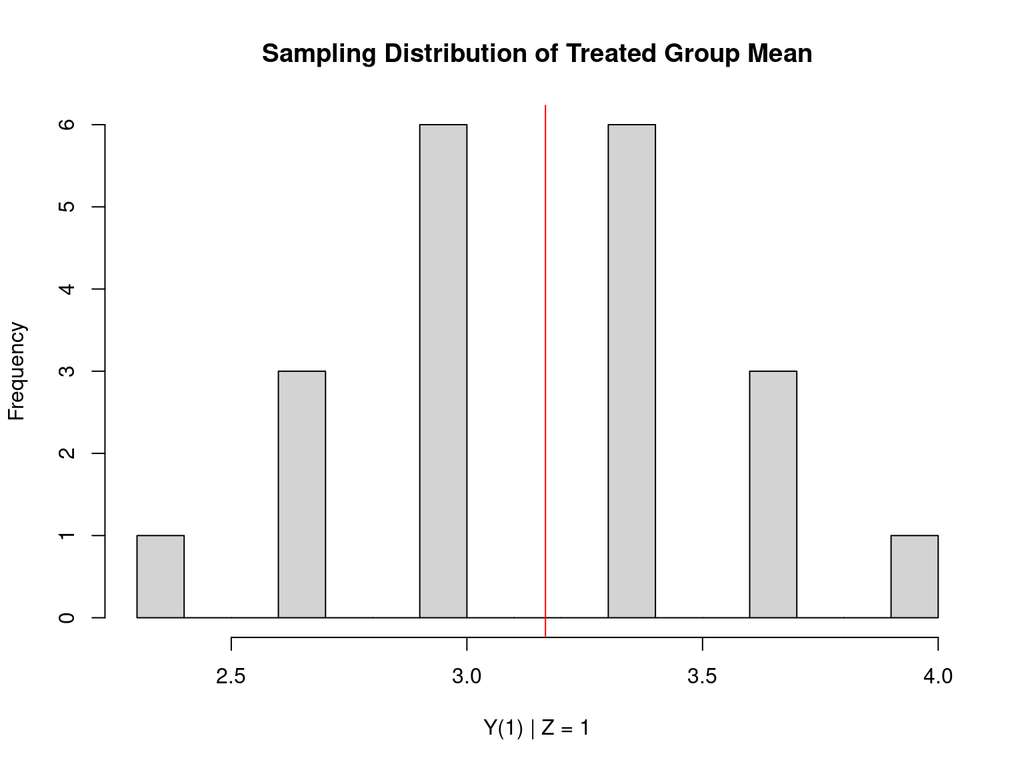

Let’s check our work:

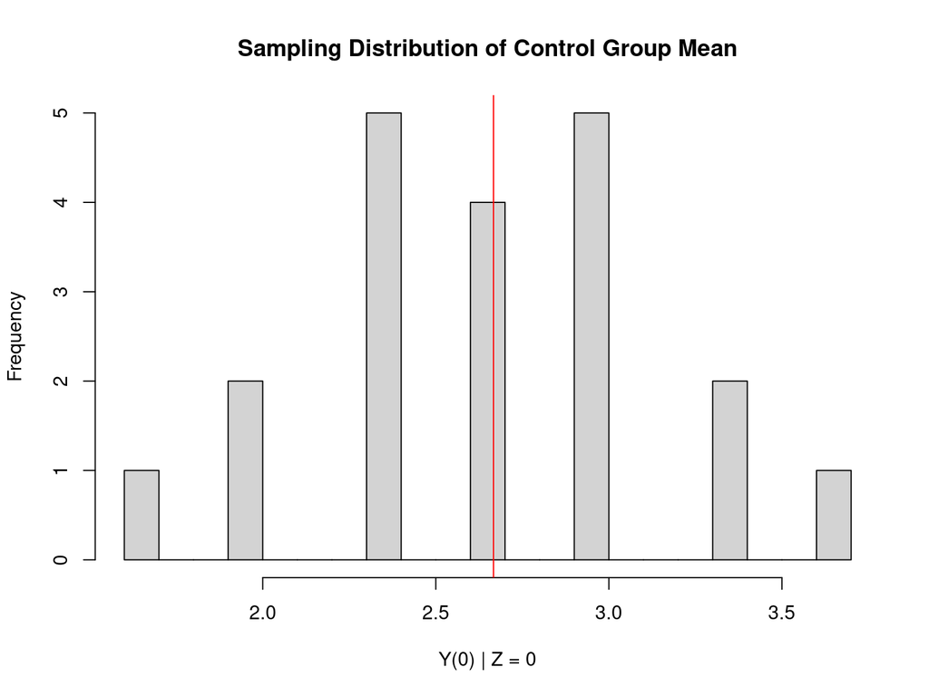

Let’s check our work:

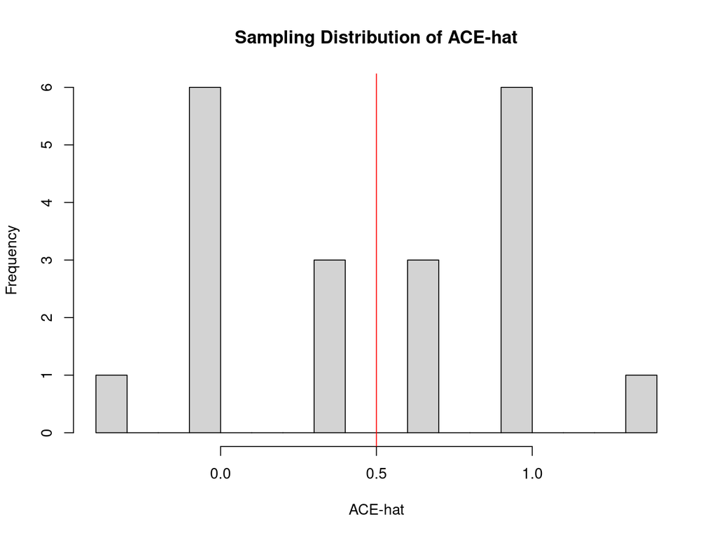

### Summary:

1. Sample Difference in Means in **unbiased**
   - mean of the **sampling distribution** of **sample** $\widehat{ACE}$ is same as **population** $ACE$
   - yet **none** of the samples estimate population $ACE$ exactly.
2. Histogram is the **exact sampling distribution** of the $\widehat{ACE}$ in this experiment
   - shows us how likely it is we observe sample $\widehat{ACE}$ by chance (using this randomization scheme)

### Summary:

This sampling distribution could tell us

- how likely we are to observe $\widehat{ACE}$ by chance
- variability in estimate $\widehat{ACE}$
- also the true $ACE$

But we never observe this histogram

- we need a way to **estimate** the sampling distribution of $\widehat{ACE}$.

# Variance of $\widehat{ACE}$

## Three approaches

1. Analytic/Asymptotic approach
2. Randomization inference
3. Bootstrap

## Three approaches

All approaches involve:

- assuming a particular process of randomization by which realizations from random variable are created
- need to answer:
- what do we want to make inferences about? the study cases or a broader population (randomness in which cases we see)? counterfactuals (randomness in which potential outcomes we see)?
- what process generates the randomness? (sometimes this is clear, sometimes not at all)

## Analytic Approach

**First**: we want to get variance of $\widehat{ACE}$

- $\widehat{ACE}$ is a **difference** of random variables. **Why?**
- Need rules for calculating variance of **difference** between random variables

$$Var[X - Y] = Var[X] + Var[Y] - 2 \cdot
Cov[X,Y]$$

### Analytic Approach

- **study group** of size $N$ ($N$ units are assigned)
- $m$ units assigned to T; $N - m = n$ units assigned to C
- $Y^T = \frac{1}{m}\sum\limits_{i=1}^{m}[\overbrace{Y_i(1) | Z_i = 1}^{\mathrm{observed \ Y \ for \ Treated}}]$
- $Y^C = \frac{1}{n}\sum\limits_{i=m+1}^{N}[\underbrace{Y_i(0) | Z_i= 0}_{\mathrm{observed \ Y \ for \ Control}}]$
- $\widehat{ACE} = Y^T - Y^C$

What is $Var[Y^T - Y^C] = Var[\widehat{ACE}]$?

- $Var[Y^T - Y^C] = Var[Y^T] + Var[Y^C] - 2 Cov[Y^T, Y^C]$

### Analytic Approach

**Variances of Treatment/Control Group Means**

if we assume **independent and identically distributed** draws from the **study group**

- (is this correct?)

$$Var[Y^T] =
\frac{Var[Y_i(1)]}{m}$$

Variance of **sampling distribution** of the **treatment-group mean** is variance of potential outcomes under treatment for **all cases** divided by the treatment group size

### Analytic Approach

Variance of potential outcomes under treatment:

$$Var[Y_i(1)] =
\frac{1}{N}\sum\limits_{i=1}^{N} \left( Y_i(1) -
\overbrace{\frac{\sum\limits_{i=1}^{N} Y_i(1)}{N}}^{mean \ Y_i(1)}
\right) ^2$$

This is a *parameter*, often denoted $\sigma^2$

$$Var[Y^T] =
\frac{\sigma^2}{m}$$

- Why is $\sigma^2$ a parameter?

### Analytic Approach

We don’t know $\sigma^2$, we need to **estimate** it from our **sample**.

Like sample mean, sample variance is an unbiased estimator of population variance:

- **if we divide by $m - 1$ not $m$**

$$\widehat{Var[Y_i(1)]} =
\widehat{\sigma^2} =
\frac{1}{\color{red}{m-1}}\sum\limits_{i=1}^{m}[Y_i(1) | Z_i = 1] -
Y^T)^2$$

### Digression

Why is sample variance biased if we divide by $m$ (instead of $m-1$)?

- the mean is the value that minimizes the sum of squared errors
- If the sample mean $\hat\mu$ $\neq$ population mean $\mu$, then $\left[ \sum\limits_{i = 1}^{m} [x_i - \hat\mu]^2 \right] < \left[ \sum\limits_{i = 1}^{m} [x_i - \mu]^2 \right]$
- **Uncorrected** sample variance $\widehat{\sigma^2}$ is $\frac{1}{m} \sum\limits_{i = 1}^{m} [x_i - \hat\mu]^2$.
- Then, $\widehat{\sigma^2} < \sigma^2$ unless sample mean equals population mean

### Digression

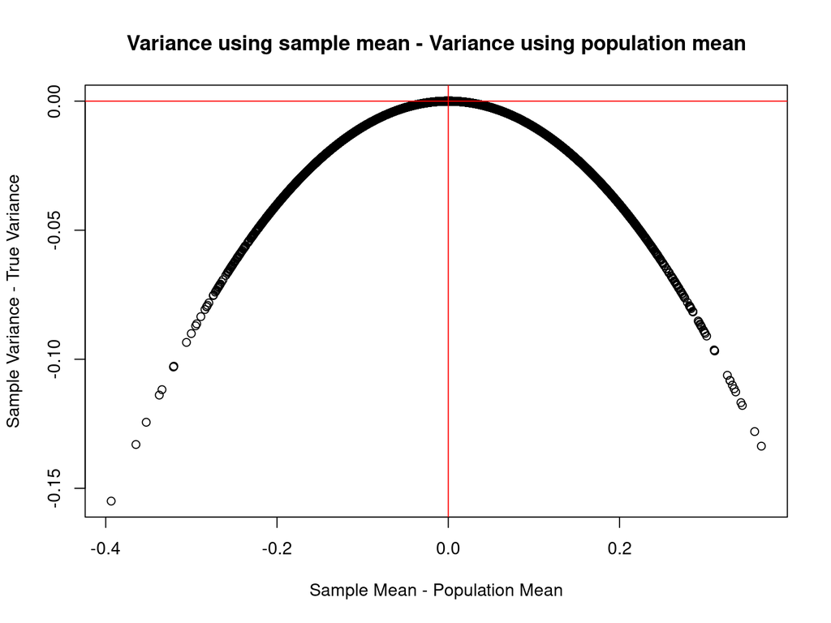

### Analytic Approach

Using this approach:

$$\widehat{Var[Y_i(1)]} =
\widehat{\sigma^2} = \frac{1}{m-1}\sum\limits_{i=1}^{m}[Y_i(1) | Z_i =
1] - Y^T)^2$$

$$\widehat{Var[Y^T]} =
\frac{\widehat{\sigma^2}}{m}$$

we can **estimate** $Var(Y^T)$ and $Var(Y^C)$.

What else do we need to estimate $Var[\widehat{ACE}]$?

### Analytic Approach

We still need $Cov(Y^T,Y^C)$ to get variance of $\widehat{ACE}$, because

$Var[\widehat{ACE}] = Var[Y^T] + Var[Y^C] - 2 Cov[Y^T, Y^C]$

$$Cov(Y^T,Y^C) =
-\frac{1}{N(N-1)}\sum\limits_{i=1}^{N} \left( Y_i(1) -
\overbrace{\frac{\sum\limits_{i=1}^{N} Y_i(1)}{N}}^{mean \ Y_i(1)}
\right) \cdot \left(Y_i(0) - \overbrace{\frac{\sum\limits_{i=1}^{N}
Y_i(0)}{N}}^{mean \ Y_i(0)} \right)$$

- **Can we estimate this?**

### Analytic Approach

Can’t estimate the covariance because we don’t see both potential outcomes for each case!

- What can we do?

### Analytic Approach

1. Estimator $\widehat{Var[Y^T]}$ ignores that we sample **without replacement** from **finite** population ($\to$ **estimated variance too large**)
2. This either **exactly** or **more than** offsets the amount by which ignoring $Cov(Y^T,Y^C)$ makes our estimate $\widehat{Var}(\widehat{ACE})$ **too small**

### Analytic Approach

Variances we obtain with $\widehat{Var}[\widehat{ACE}]$ are going to be:

- **exactly correct** (if $\tau_i$ is the same for all $i$; effect is same for all cases)
- **TOO LARGE**, conservative in all other cases.

### Analytic Approach

We’ve been trying to estimate the **variance** of the $\widehat{ACE}$.

Variance is not usually what we want

- units are squared.
- The **standard error** (**standard deviation of the sampling distribution**) of $\widehat{ACE}$ is more helpful. It is the square-root of the **variance**.
- Usually, though, we want to do a **hypothesis test** or create confidence intervals

# Hypothesis Testing

### Normal approximation:

Per the **Central Limit Theorem**: the **sampling distributions** of **sums of random variables** (and by extension, their means) **approach** the normal distribution as the $N \rightarrow\infty$.

Using this fact; estimated sample mean and variance of the sample mean:

- Use the area under the normal (usually $t$: why?) curve to get compute chance of observing sample mean by chance, given a **null hypothesis**.

This approximation performs well, but depends on **sample size** and **population distribution**.

### Normal approximation:

If the **population** looks like this:

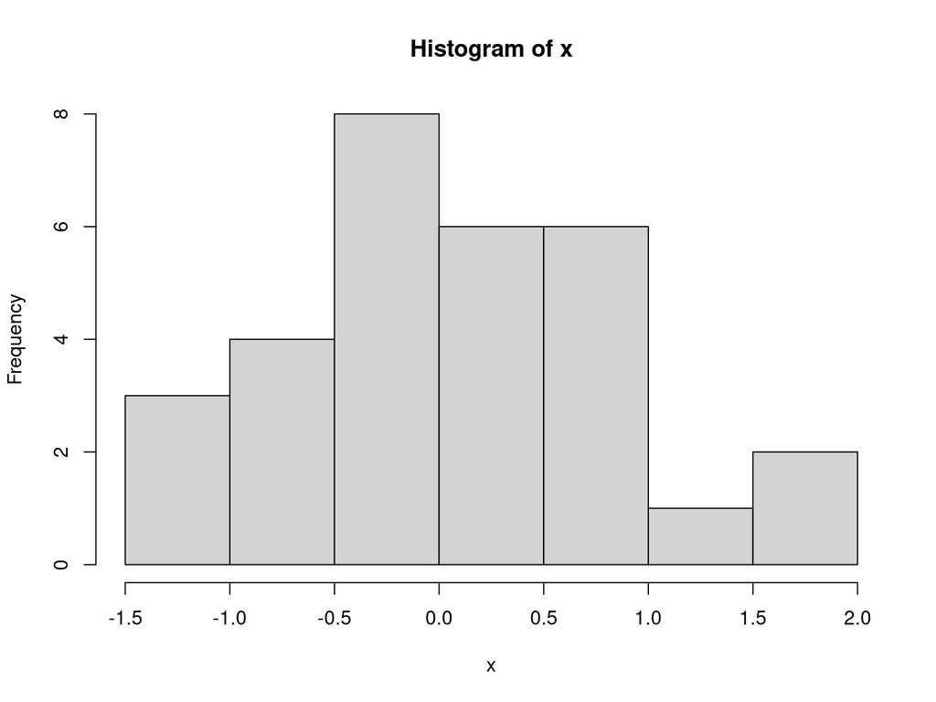

### Normal approximation:

Predict the shape of sampling distribution of sample mean for $(n= 5$)

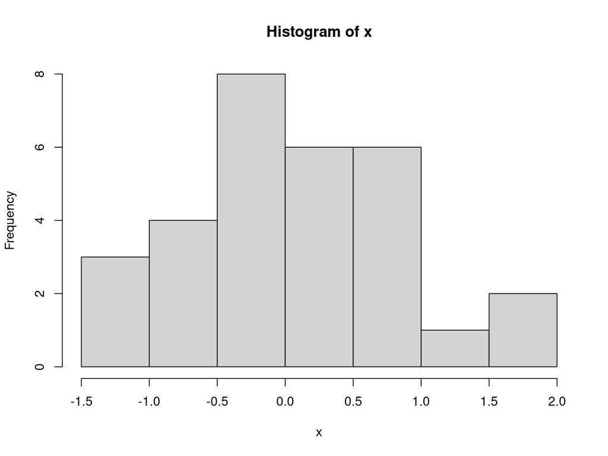

### Normal approximation:

The shape of sampling distribution of sample mean for $(n= 5$)

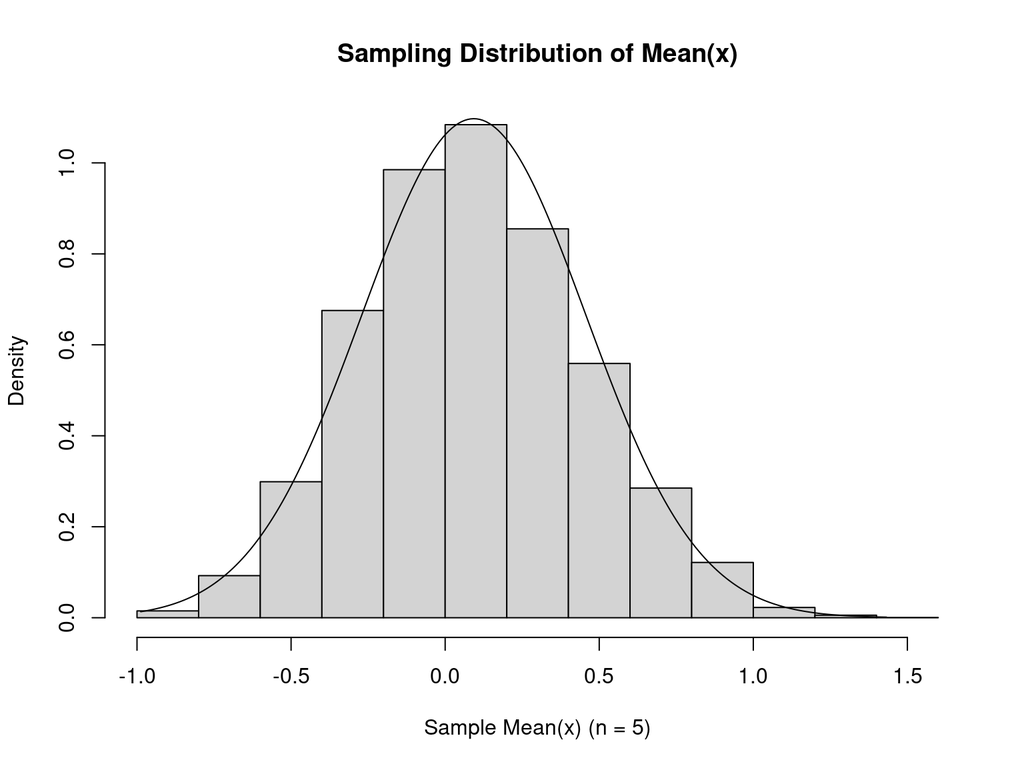

### Normal approximation:

If the **population** looks like this:

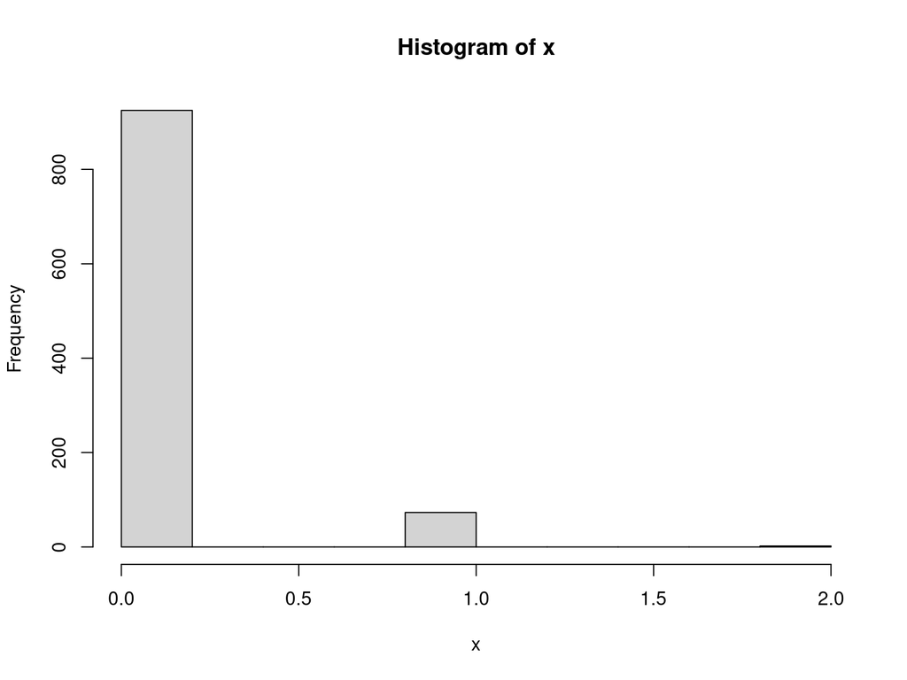

### Normal approximation:

Predict the shape of sampling distribution of sample mean for $(n= 5$)

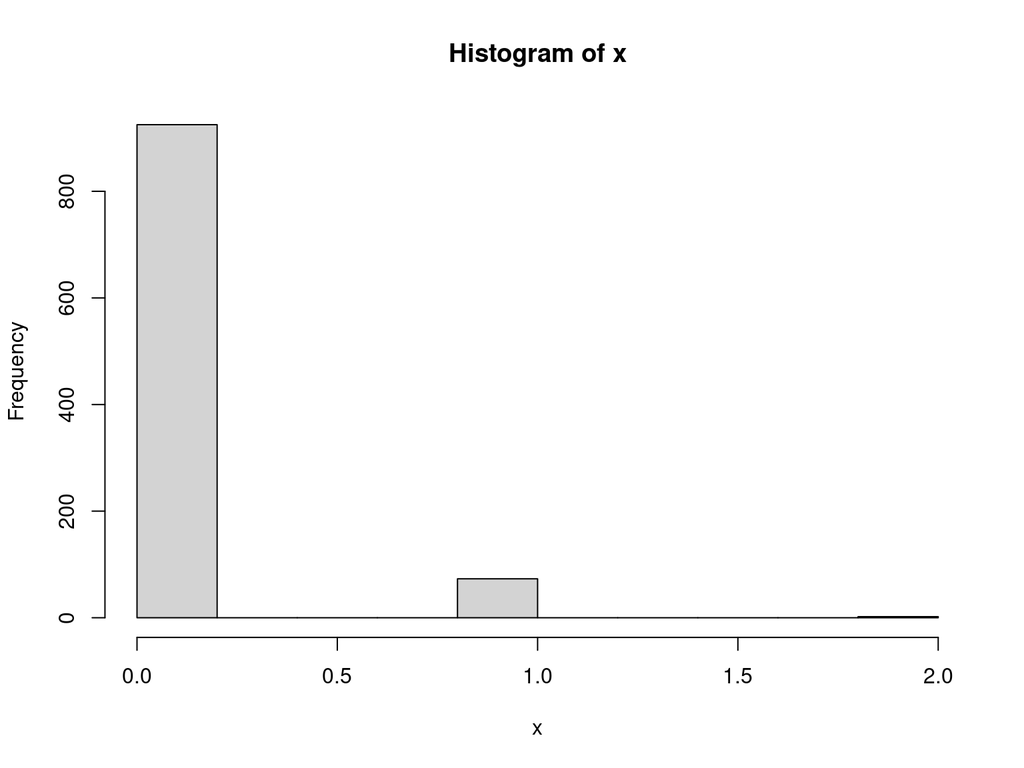

### Normal approximation:

The shape of sampling distribution of sample mean for $(n= 5$)

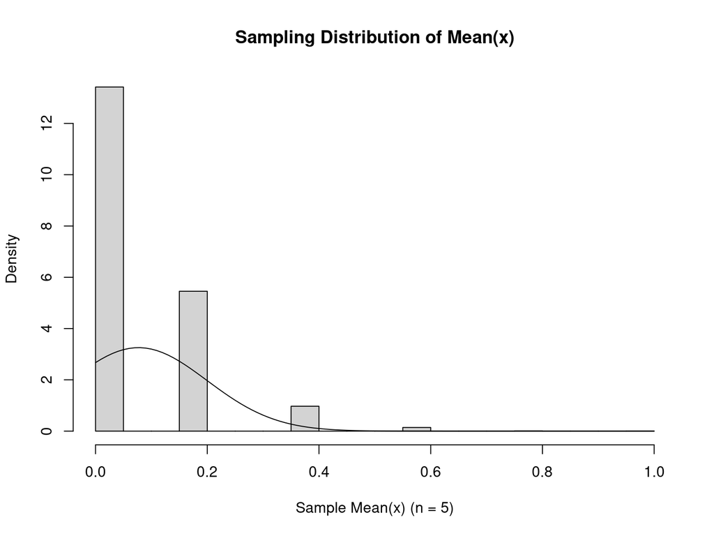

### Normal approximation:

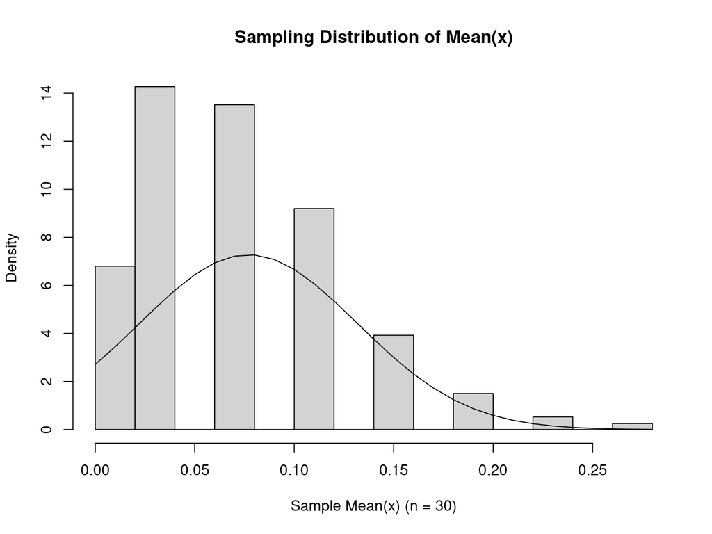

### Normal approximation:

The sampling distribution of sample mean for $(n= 100$) is

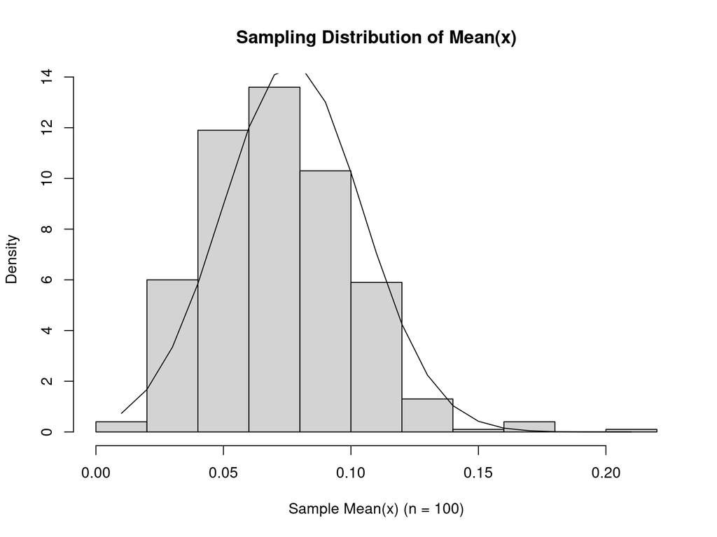

### Normal approximation:

Does normality hold in our experiment?

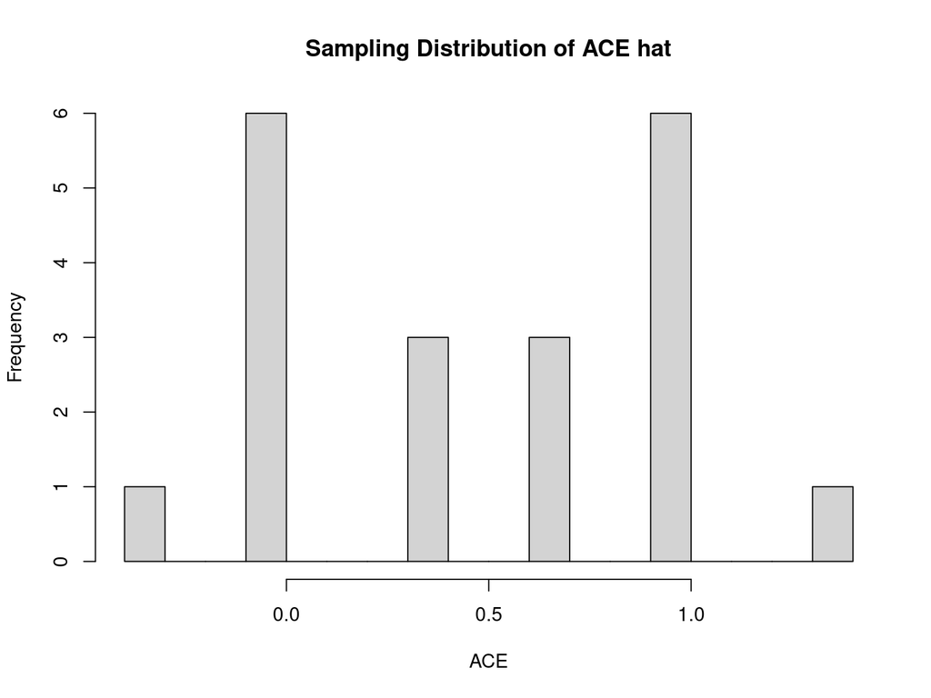

### Normal approximation:

Does normality hold in our experiment?

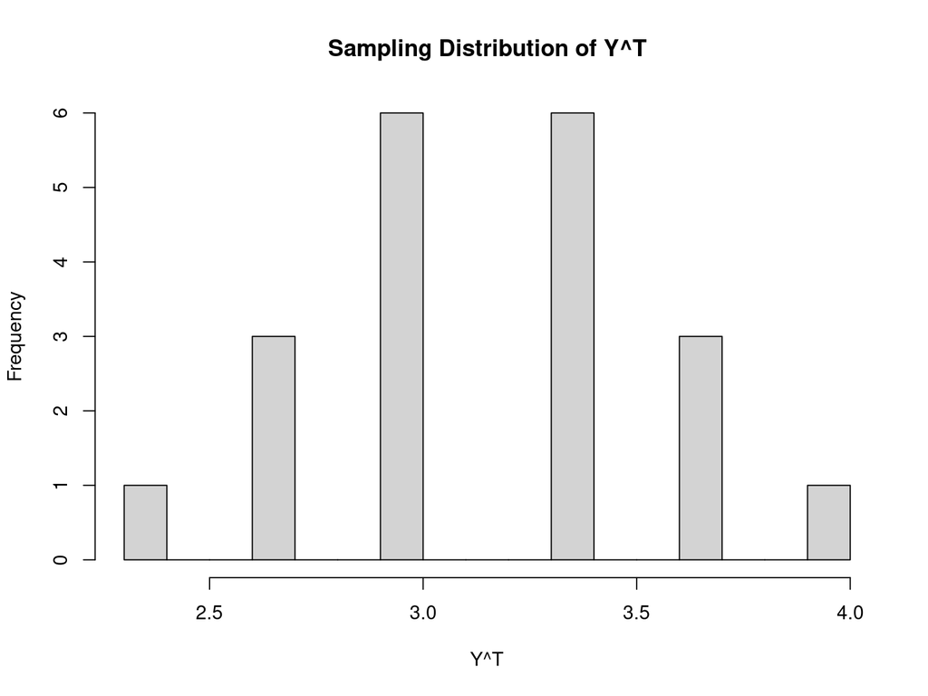

### Normal approximation:

Does normality hold in our experiment?

[figure not shown]

### Hypothesis Tests

We run an experiment on our 6 regions, and observe $\widehat{ACE} = 0.667$

The hypothesis test investigates: what is probability of observing a value this large or larger if the true $ACE = 0$

- **Null hypothesis** $H_0$ is $ACE = 0$
- **alternative hypotheses** are $ACE > 0$ or $ACE < 0$ or $ACE \neq 0$.

### Hypothesis Tests

- choose an $\alpha$: arbitrary cutoff for rejecting null hypothesis
- We need to estimate the standard error of ACE: $\widehat{SE}(\widehat{ACE})$
- Divide $\widehat{ACE}$ by $\widehat{SE}$ (get $t$ statistic).
- Compare test-statistic against $t$ distribution with appropriate degrees of freedom, calculate $p$ value (interpretation depends on the alternative hypothesis)
- and reject/fail to reject null (given choice of $\alpha$: the significance level)

### Limitations of Analytical Hypothesis Tests

- $t$-tests assume **normality** in potential outcomes
- or assume **asymptotic** normality of sampling distribution of sample mean. This may be incorrect with small $N$ or complex designs. (What about in our example?)

If distributional assumptions are wrong, hypothesis test will not be correct

- need to investigate plausibility of assumption:
  - is $N$ large?
  - Are values of $Y(1) | Z=1$ and $Y(0) | Z =0$ approximately normal?

### Limitations of Analytical Hypothesis Tests

Alternatives:

**bootstrap**

**randomization inference**

# Randomization Inference

### Randomization Inference

Unlike analytical approach:

- randomization inference **does not assume** any asymptotic distribution
- can be applied to many different estimators (not just, e.g., the $\widehat{ACE}$)

### Randomization Inference

Tests a **different null** hypothesis

Usually null hypothesis is that the **average** effect is $0$ (some units could have positive or negative effects).

$$\frac{1}{N}\sum\limits_{i=1}^{N} \tau_i
= ACE = 0$$
Randomization inference tests the **sharp null hypothesis**

$$\tau_i = 0 \ \ \ \forall \ \ \ (i\ \in
N)$$
that **every** unit treatment effect is $0$.

### Randomization Inference

Advantages:

- No assumptions about distributions (no assumption of normality, no asymptotic convergence)
- directly flows from potential outcomes model
- any test statistic (median, ranks, whatever)

Disadvantages

- only tests **sharp null** which may be less interesting$^*$
- Confidence intervals only for **constant effects**
- $p$ values limited by possible combinations (too few, and they are coarse, too many, they are approximate)

### Randomization Inference

In practice:

- Null hypothesis of **sharp null** lets us **complete** the potential outcomes table/response schedule based on the observed data
- Why?
- Sharp null implies that $Y_i^1 = Y_i^0$ for all units $i$.

### Randomization Inference

We run Paluck’s experiment and see this:

| $Region_i$ | $Y_i(1)$ | $Y_i(0)$ |
| --- | --- | --- |
| 1 | 3 | ? |
| 2 | 4 | ? |
| 3 | ? | 2 |
| 4 | 2 | ? |
| 5 | ? | 4 |
| 6 | ? | 1 |

Under the **sharp null**, what are the values that are “?”?

### Randomization Inference

Under the **sharp null**, this would be true:

| $Region_i$ | $Y_i(1)$ | $Y_i(0)$ |
| --- | --- | --- |
| 1 | 3 | $\color{red}{3}$ |
| 2 | 4 | $\color{red}{4}$ |
| 3 | $\color{red}{2}$ | 2 |
| 4 | 2 | $\color{red}{2}$ |
| 5 | $\color{red}{4}$ | 4 |
| 6 | $\color{red}{1}$ | 1 |

### Randomization Inference

Once we have this response schedule **under the sharp null**, we:

1. Create all possible permutations of randomizations (or sample them, if this number is large)
2. Calculate the difference in means (or other statistic) for these different randomizations.
3. Compare our **observed statistic** against this **null distribution** (distribution of $\widehat{ACE}$ that could have occurred by chance assuming the sharp null hypothesis is true)
4. Calculate $p$ value based on fraction of outcomes in null distribution more extreme than observed outcome.

## Randomization Inference

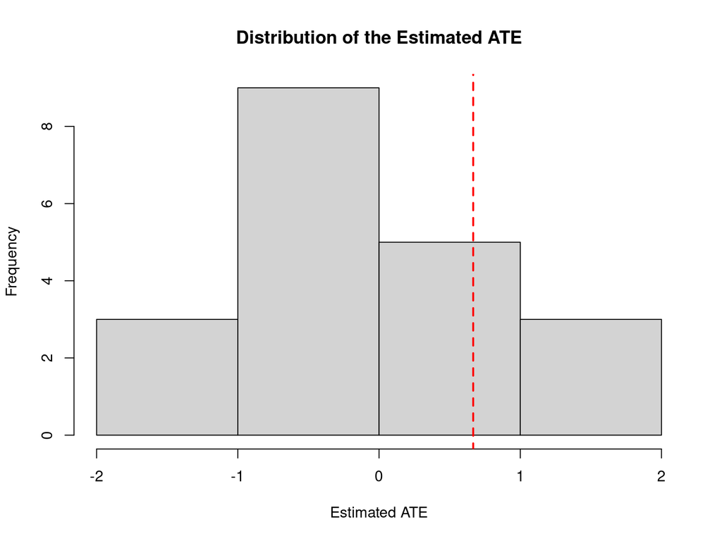

## Randomization Inference

If $\widehat{ACE}=$ 0.6666667, then $p(ACE != 0)$ is 0.8.

In `R`:

```r
#install.packages('ri')
require(ri)
```